# Voice agent leads outreach

# Vapi, Open AI, Clickup, Airtable, Google Drive

99fold | matt@99foldai.com | @99foldai

# Summary

An automated outbound calling process using a voice AI agent, integrated with client database systems like Airtable or ClickUp. Voice agent is triggered to make calls, following a personalised prompt (Open AI). Outcomes are logged back into the database for tracking and review. The voice agent operates with a clearly defined prompt — introduction, confirms business details, asks relevant questions, suggests next steps — and is trained to handle objections, offer helpful previews of templates or products with no sales pressure. The review phase includes assessing results and refining the process as needed.

# Who is this perfect for?

## Service provider

## Sales teams

## Recruitment agency

## Brick and mortar business

## Sport clubs

## Tourism agency

# How does it work?

1. Connect to client database (Airtable, Clickup)  
   Connect to your custom client database app
2. Process retrieved data  
   Analyse and prepare the retrieved data for the outbound phone call process
3. Initiate voice agent workflow (outbound calls) with Open AI personalisation  
   Trigger voice agent action and prompts (see below schematic)
4. Log call results  
   Record the outcomes of each call in database (Clickup, Auirtable)
5. Review/adjust summary  
   Assess the results and make necessary adjustments to the workflow as needed

Option 2

1. Set up voice agent to handle incoming calls/applications/EOIs  
   Qualify leads with set screening questions based on user convenience (timezone agnostic)
2. Store transcript in database (Airtable, Clickup)  
   Link to your current database and auto collect relevant responses
3. Analyse transcript by team members/HR  
   Pass to people to filter final shortlist and book call/interview

**Voice agent Open AI instructions**

1. Identity and purpose  
   Introduction and general scope and purpose of call
2. Voice and personality  
   Friendly, relaxed, and curious with a natural, human, conversational tone
3. Speech parameters  
   Begin casually, explain the aims of your business, and ask for basic info
4. Conversation semantics  
   Ask one question at a time, confirm details, and close with warmth and respect
5. Response instructions  
   Adapt to questions or objections with honesty and appreciation, no pressure
6. Scenario triage  
   Show pre-built templates/products, no cost or sales, only a helpful preview

#### Check out more automations like this at [**99fold**](https://www.99foldai.com)

# Pathway

Low-friction integration with your existing apps, workflow, and systems

[figure not shown]

[figure not shown]

[figure not shown]

[figure not shown]

[figure not shown]

# Process

[figure not shown]

> Connect your existing client database, such as Clickup, Airtable, Google Sheets

> Personalised voice agent to handle outreach and support/FAQs

[figure not shown]

[figure not shown]

> Call data analysis for further refinements and improved workflow

#### Check out more automations like this at [**99fold**](https://www.99foldai.com)

# More benefits

### Tasks

- Automatically connect to your current client database with no need for separate apps
- Trigger outbound calls via a trained voice AI agent using personalized, objection-handling scripts
- Log call outcomes directly into your system for real-time tracking and follow-up actions

### Benefits

- Boost lead engagement and conversions by reaching more prospects with no added team bandwidth
- Streamline outbound processes with consistent, human-like AI calls
- Gain data-driven insights to refine messaging, improve targeting, and optimize outreach strategies

# Example

Example of automated workflow (replace with your own tasks/apps)

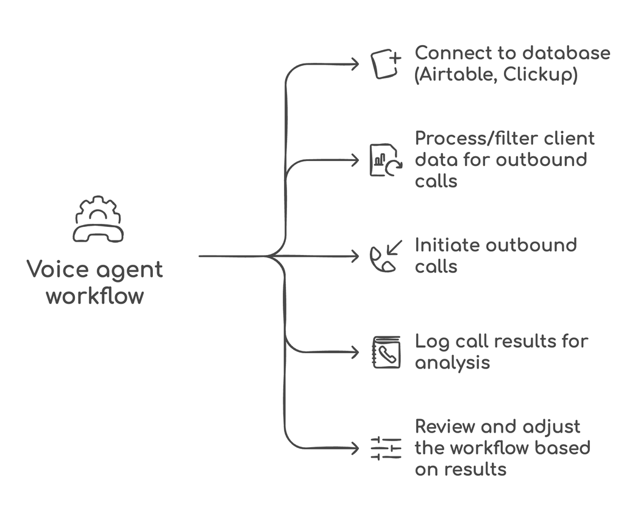

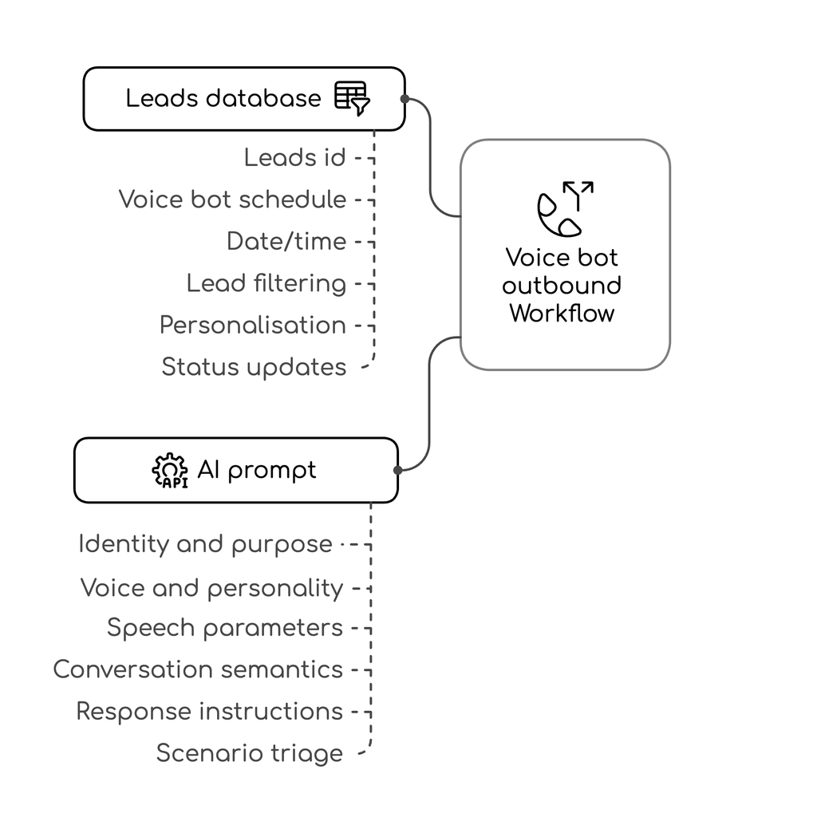

#### Check out more automations like this at [**99fold**](https://www.99foldai.com)

Another automation by 99fold